# Project 2: Data Mining, Classification, Prediction

SDS322E

# Mining, Classification, Prediction

## Wesley Lu, wl8838

### Introduction

Happiness is an essential aspect in life. While the definition of happiness is highly subjective, I selected a dataset of global happiness to investigate factors that may contribute to one’s happiness. `Happiness Score` is a numerical variable measuring happiness levels. There are 6 additional numerical variables that act as happiness indicators for each country (observation). `Region` is a categorical variable representing a broader geographical location that a country resides in. There are 10 different groups in this variable with 5 groups having more than 15 countries and the other 5 groups having less than 10 countries. The dataset was originally obtained from Kaggle that lacked a binary variable. Coming from an Asian immigrant family, I created a binary variable, `Asia`, from the `Region` variable entailing whether an observation resides in Asia. In this variable, 22 countries belongs in Asia, and 135 countries do not.

```r
library(tidyverse)
# read your datasets in here, e.g., with read_csv()
data <- read_csv("2016.csv")

# if your dataset needs tidying, do so here create a binary
# variable
happy <- data %>% mutate(Asia = ifelse(str_detect(Region, "Asia"),
    1, 0)) %>% select(-c(`Happiness Rank`, `Lower Confidence Interval`,
    `Upper Confidence Interval`))
happy <- happy %>% column_to_rownames(var = "Country")

# any other code here
happy %>% group_by(Region) %>% summarize(n())
```

```
## # A tibble: 10 x 2
##    Region                          `n()`
##    <chr>                           <int>
##  1 Australia and New Zealand           2
##  2 Central and Eastern Europe         29
##  3 Eastern Asia                        6
##  4 Latin America and Caribbean        24
##  5 Middle East and Northern Africa    19
##  6 North America                       2
##  7 Southeastern Asia                   9
##  8 Southern Asia                       7
##  9 Sub-Saharan Africa                 38
## 10 Western Europe                     21
```

```r
happy %>% group_by(Asia) %>% summarize(n())
```

```
## # A tibble: 2 x 2
##    Asia `n()`
##   <dbl> <int>
## 1     0   135
## 2     1    22
```

### Cluster Analysis

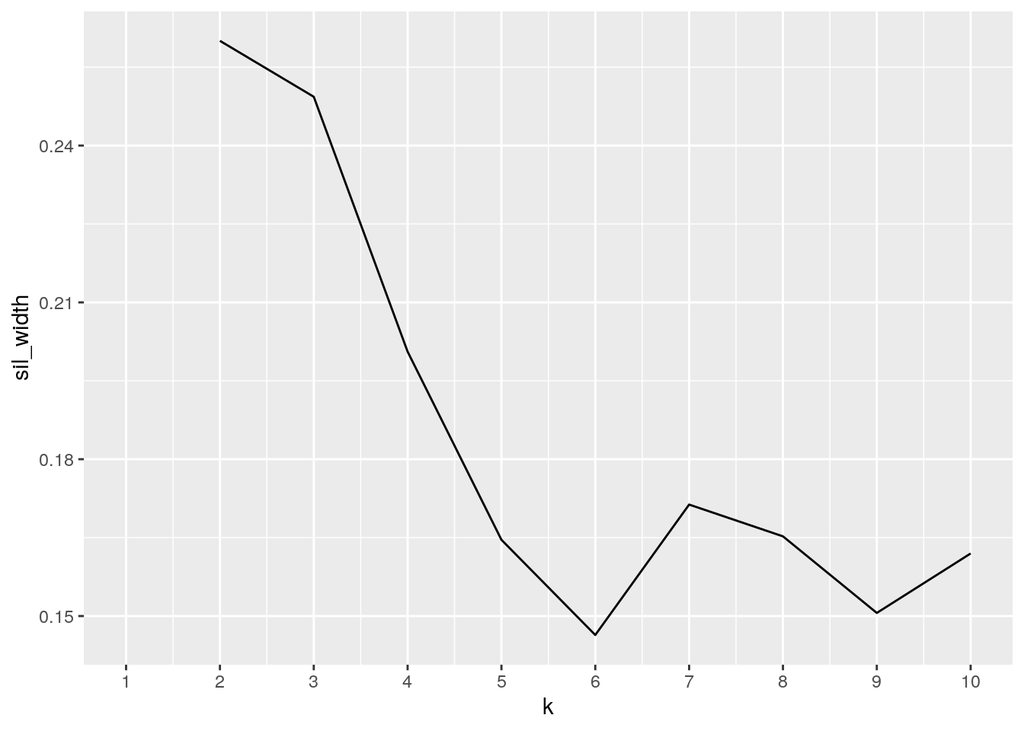

```r
library(cluster)
library(GGally)

# clustering code here
dat <- happy %>% select(c(`Happiness Score`:`Dystopia Residual`)) %>%
    scale

# average silhouette width
sil_width <- vector()
for (i in 2:10) {
    pam_fit <- pam(dat, k = i)
    sil_width[i] <- pam_fit$silinfo$avg.width
}
ggplot() + geom_line(aes(x = 1:10, y = sil_width)) + scale_x_continuous(name = "k",
    breaks = 1:10)
```

```r
# PAM clustering
final <- dat %>% pam(2)
final
```

[output not shown]

[output cut: 32 more lines]

[output not shown]

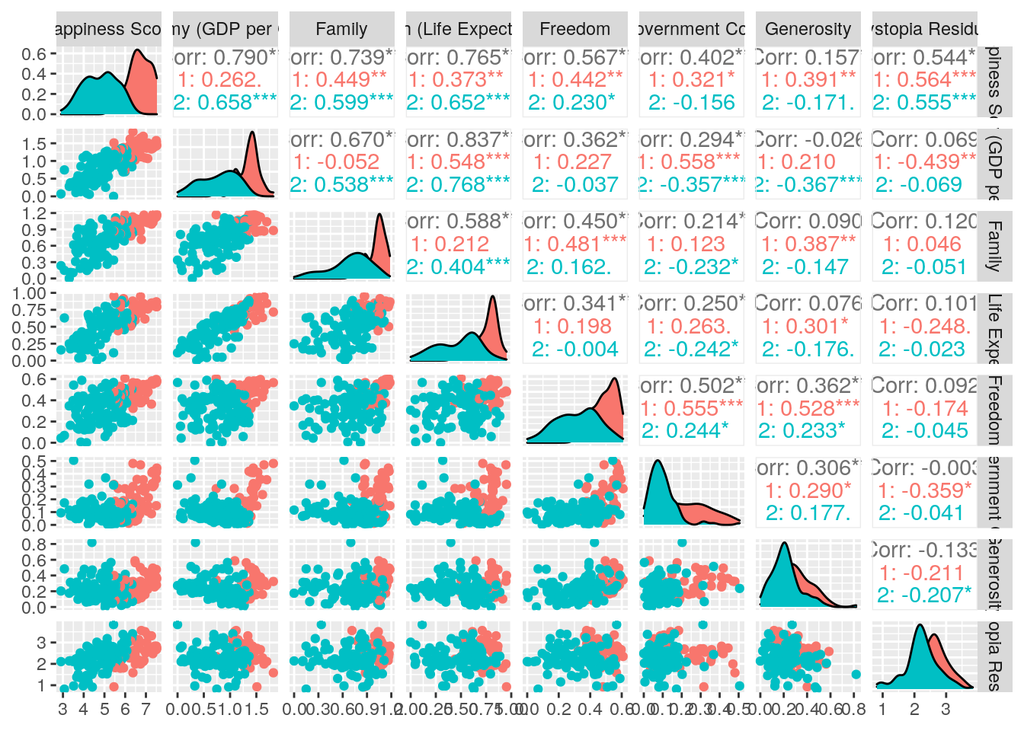

```r
happy %>% mutate(cluster = as.factor(final$clustering)) %>% ggpairs(columns = 2:9,
    aes(color = cluster))
```

```r
# goodness of fit of the cluster solution
final$silinfo$avg.width
```

```
## [1] 0.260035
```

Based on the maximum average silhouette width, the number of clusters was determined to be 2 with Belgium being the representative of cluster 1 (red) and Honduras being the the other (blue). Using ggpairs, the two clusters showed significant difference in distributions of `Happiness Score`, `Economy`, `Family`, `Health`, `Freedom`, and `Trust in Government` and fairly overlapped distributions in `Generosity` and `Dystopia Residual`. Specifically, cluster 1 is happier, wealthier, more family support, healthier, experiencing more freedom and less government control. Cluster 2 is less happier, poorer, less family support, less healthier, experiencing less freedom and more government control. Goodness of fit of the cluster solution was determined to be 0.26, indicating that the structure is weak and could be from noise.

### Dimensionality Reduction with PCA

```r
# PCA code here
happy_pca <- princomp(dat, cor = T)
summary(happy_pca, loadings = T)  #get PCA summary
```

```
## Importance of components:
##                           Comp.1    Comp.2    Comp.3     Comp.4    Comp.5
## Standard deviation     1.9472672 1.2061241 1.0303030 0.81896823 0.7241564
## Proportion of Variance 0.4739812 0.1818419 0.1326905 0.08383862 0.0655503
## Cumulative Proportion  0.4739812 0.6558231 0.7885136 0.87235226 0.9379026
##                            Comp.6     Comp.7       Comp.8
## Standard deviation     0.59667064 0.37518478 2.110583e-04
## Proportion of Variance 0.04450198 0.01759545 5.568201e-09
## Cumulative Proportion  0.98240454 0.99999999 1.000000e+00
##
## Loadings:
##                               Comp.1 Comp.2 Comp.3 Comp.4 Comp.5 Comp.6 Comp.7
## Happiness Score                0.491  0.138  0.220
## Economy (GDP per Capita)       0.439  0.196 -0.331         0.171 -0.104  0.725
## Family                         0.410  0.107 -0.165  0.230 -0.489  0.653 -0.195
## Health (Life Expectancy)       0.426  0.168 -0.292         0.388 -0.343 -0.636
## Freedom                        0.341 -0.382  0.189        -0.606 -0.565
## Trust (Government Corruption)  0.260 -0.461  0.134 -0.709  0.261  0.339
## Generosity                     0.114 -0.637  0.108  0.646  0.345         0.119
## Dystopia Residual              0.145  0.372  0.815         0.139
##                               Comp.8
## Happiness Score                0.819
## Economy (GDP per Capita)      -0.296
## Family                        -0.191
## Health (Life Expectancy)      -0.165
## Freedom                       -0.104
## Trust (Government Corruption)
## Generosity
## Dystopia Residual             -0.389
```

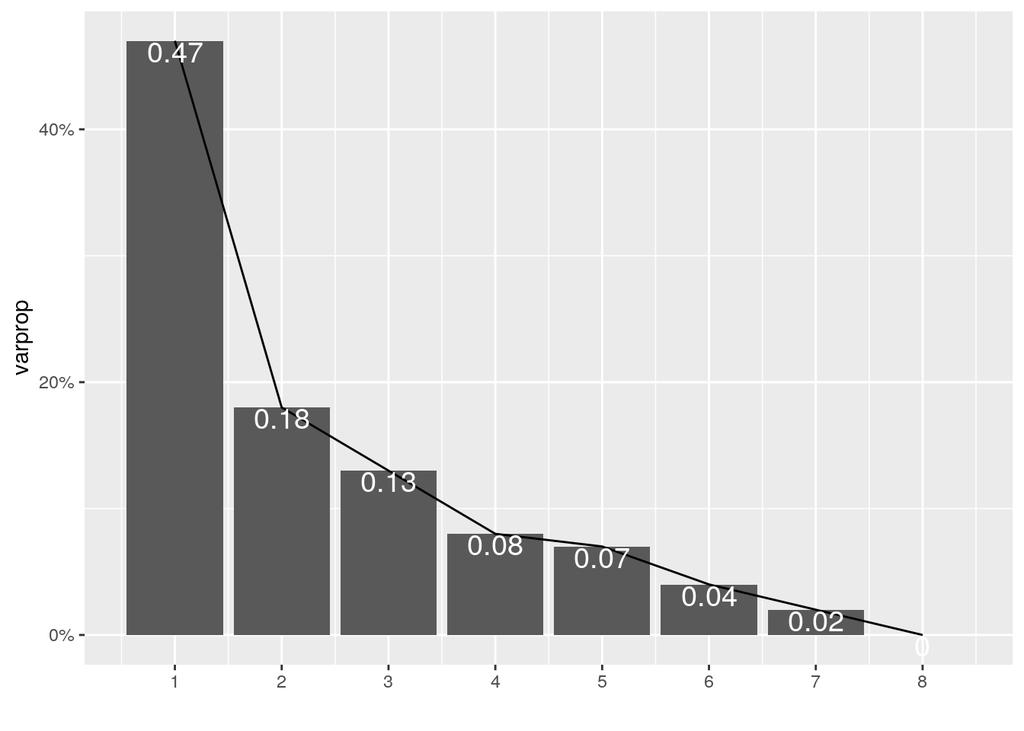

```r
eigval <- happy_pca$sdev^2  #square to convert SDs to eigenvalues
varprop = round(eigval/sum(eigval), 2)  #proportion of var explained by each PC

ggplot() + geom_bar(aes(y = varprop, x = 1:8), stat = "identity") +
    xlab("") + geom_path(aes(y = varprop, x = 1:8)) + geom_text(aes(x = 1:8,
    y = varprop, label = round(varprop, 2)), vjust = 1, col = "white",
    size = 5) + scale_y_continuous(breaks = seq(0, 0.6, 0.2),
    labels = scales::percent) + scale_x_continuous(breaks = 1:10)
```

```r
eigval
```

```
##       Comp.1       Comp.2       Comp.3       Comp.4       Comp.5       Comp.6
## 3.791850e+00 1.454735e+00 1.061524e+00 6.707090e-01 5.244024e-01 3.560158e-01
##       Comp.7       Comp.8
## 1.407636e-01 4.454561e-08
```

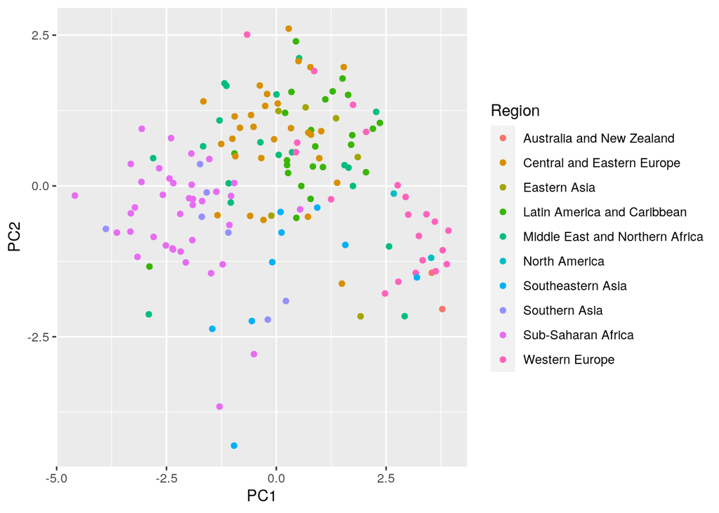

```r
# plot of PC1 and PC2
happy %>% mutate(PC1 = happy_pca$scores[, 1], PC2 = happy_pca$scores[,
    2]) %>% ggplot(aes(PC1, PC2, color = Region)) + geom_point()
```

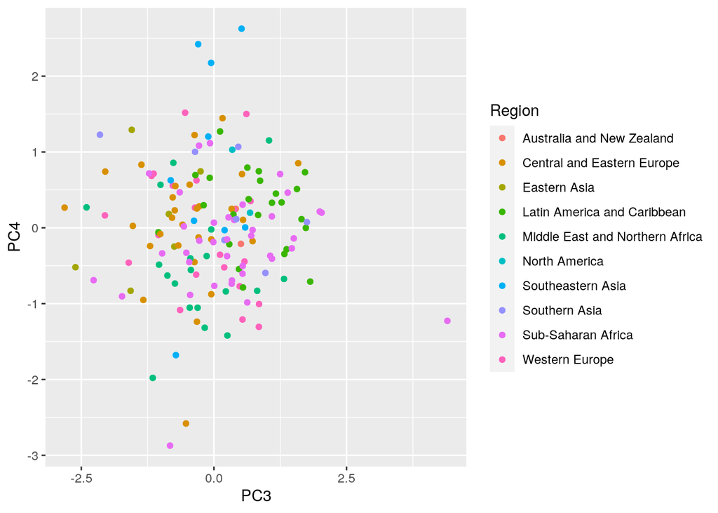

```r
# plot of PC3 and PC4
happy %>% mutate(PC3 = happy_pca$scores[, 3], PC4 = happy_pca$scores[,
    4]) %>% ggplot(aes(PC3, PC4, color = Region)) + geom_point()
```

PCA was performed on all numeric variables as shown above. 4 PCs were retained as over 80% of the total variance (87.24%) could be explained by these PCs. A high PC1 means happier, wealthier, more family support, and more freedom. A high PC2 represents lower trust in government and lower generosity. A high PC3 means high dystpia residual. A high PC4 represents lower trust in government and high generosity.

### Linear Classifier

```r
# linear classifier code here logistic regression
class_dat <- happy %>% select(-Region)
fit <- glm(Asia ~ ., data = class_dat, family = "binomial")
score <- predict(fit, type = "response")

# confusion table
table(truth = factor(class_dat$Asia == 1, levels = c("TRUE",
    "FALSE")), prediction = factor(score > 0.5, levels = c("TRUE",
    "FALSE")))
```

```
##        prediction
## truth   TRUE FALSE
##   TRUE     7    15
##   FALSE    4   131
```

```r
class_diag(score, class_dat$Asia, positive = 1)
```

```
##           acc   sens   spec    ppv     f1     ba    auc
## Metrics 0.879 0.3182 0.9704 0.6364 0.4242 0.6443 0.8687
```

```r
# cross-validation of linear classifier here
set.seed(1234)
k = 10  #choose number of folds

data <- class_dat[sample(nrow(class_dat)), ]  #randomly order rows
folds <- cut(seq(1:nrow(class_dat)), breaks = k, labels = F)  #create 10 folds
diags <- NULL

for (i in 1:k) {
    ## Create training and test sets
    train <- data[folds != i, ]
    test <- data[folds == i, ]
    truth <- test$Asia

    ## Train model on training set
    fit <- glm(Asia ~ ., data = train, family = "binomial")
    probs <- predict(fit, newdata = test, type = "response")

    ## Test model on test set (save all k results)
    diags <- rbind(diags, class_diag(probs, truth, positive = 1))
}

summarize_all(diags, mean)  #average diagnostics across all k folds
```

```
##     acc    sens    spec ppv  f1      ba     auc
## 1 0.855 0.33333 0.95653 NaN NaN 0.64494 0.82108
```

Logistic regression was performed on the binary variable `Asia` using all the numerical variables. The model has an AUC of 0.8687, suggesting that the model has good performance in-sample. A k-Fold CV was also performed, in which the AUC was determined to be 0.82. The result suggested that the performance was worse out-of-sample, and there were signs of overfitting.

### Non-Parametric Classifier

```r
library(caret)

# non-parametric classifier code here make valid column names
colnames(class_dat) <- make.names(colnames(class_dat))

# k-nearest-neighbors
knn_fit <- knn3(factor(Asia == 1, levels = c("TRUE", "FALSE")) ~
    ., data = class_dat, k = 5)
y_hat_knn <- predict(knn_fit, class_dat)

# confusion table
table(truth = factor(class_dat$Asia == 1, levels = c("TRUE",
    "FALSE")), prediction = factor(y_hat_knn[, 1] > 0.5, levels = c("TRUE",
    "FALSE")))
```

```
##        prediction
## truth   TRUE FALSE
##   TRUE     5    17
##   FALSE    1   134
```

```r
class_diag(y_hat_knn[, 1], class_dat$Asia, positive = 1)
```

```
##            acc   sens   spec    ppv     f1     ba    auc
## Metrics 0.8854 0.2273 0.9926 0.8333 0.3571 0.6099 0.9081
```

```r
# cross-validation of np classifier here
set.seed(1234)
k = 10

data <- class_dat[sample(nrow(class_dat)), ]  #randomly order rows
folds <- cut(seq(1:nrow(class_dat)), breaks = k, labels = F)  #create 10 folds
diags <- NULL

for (i in 1:k) {
    ## Create training and test sets
    train <- data[folds != i, ]
    test <- data[folds == i, ]
    truth <- test$Asia

    ## Train model on training set
    fit <- knn3(Asia ~ ., data = class_dat)
    probs <- predict(fit, newdata = test)[, 2]

    ## Test model on test set (save all k results)
    diags <- rbind(diags, class_diag(probs, truth, positive = 1))
}

summarize_all(diags, mean)
```

```
##       acc    sens    spec ppv  f1      ba     auc
## 1 0.88624 0.21666 0.99231 NaN NaN 0.60449 0.92229
```

### Regression/Numeric Prediction

```r
# regression model code here
fit <- lm(`Happiness Score` ~ Family + Freedom, data = happy)
yhat <- predict(fit)  #predicted happiness score

mean((happy$`Happiness Score` - yhat)^2)  #mean squared error (MSE)
```

```
## [1] 0.4983942
```

```r
# cross-validation of regression model here
set.seed(1234)
k = 5  #choose number of folds

data <- happy[sample(nrow(happy)), ]  #randomly order rows
folds <- cut(seq(1:nrow(happy)), breaks = k, labels = F)  #create folds
diags <- NULL

for (i in 1:k) {
    train <- data[folds != i, ]
    test <- data[folds == i, ]
    ## Fit linear regression model to training set
    fit <- lm(`Happiness Score` ~ Family + Freedom, data = train)
    ## Get predictions/y-hats on test set (fold i)
    yhat <- predict(fit, newdata = test)
    ## Compute prediction error (MSE) for fold i
    diags <- mean((test$`Happiness Score` - yhat)^2)
}
mean(diags)  ## get average MSE across all folds (much higher error)!
```

```
## [1] 0.6260582
```

### Python

```r
library(reticulate)

use_python("/usr/bin/python3", required = F)
happiness <- happy$`Happiness Score`
```

```python
# python code here
tot = sum(r.happiness)
```

```r
avg = py$tot/length(happiness)
avg
```

```
## [1] 5.382185
```

Column `Happiness Score` was extracted in a R code chunk. Then, the sum of this column was calculated in a python code chunk. Lastly, the average value was calculated in another R code chunk by dividing the sum by the number of items in that column.